# Final Assgnment SQL/R/Math

Puneet Auluck

July 24, 2015

### **Export WorkTravel Data**

Data: WorkTravel  
My commute consists of roughly 2 hours to work and 2 hours back.  
Method1: Bus-Train with wait and traffic time  
Method2: Train-Ferry with wait but no traffic time  
Method3: Car with no wait but traffic time

The data was inserted in Postgres DB and then exported to csv file: worktravel.csv. The data covers 3 weeks where each week consists one of the routes described above.

```r
wt <- read.table("C:\\worktravel.csv", sep=",", header = TRUE)
head(wt)
```

```
##   traveldate traveltype routeid waittime traffictime     method traveltime
## 1 2015-06-29    Leaving      R1       10           0 Bus-Trains         95
## 2 2015-06-29   Arriving      R1       15          15 Bus-Trains         95
## 3 2015-06-30    Leaving      R1       10           0 Bus-Trains         95
## 4 2015-06-30   Arriving      R1       20          15 Bus-Trains         95
## 5 2015-07-01    Leaving      R1        5           0 Bus-Trains         95
## 6 2015-07-01   Arriving      R1        0          10 Bus-Trains         95
##   travelcost
## 1       6.75
## 2       6.75
## 3       6.75
## 4       6.75
## 5       6.75
## 6       6.75
```

### **Summarize data**

```r
suppressMessages(require(plyr))
wt_sub_tr <- data.frame(type = wt$traveltype, method = wt$method,
                        totaltime = wt$traffictime + wt$waittime + wt$traveltime,
                        cost = wt$travelcost)
head(wt_sub_tr)
```

```
##       type     method totaltime cost
## 1  Leaving Bus-Trains       105 6.75
## 2 Arriving Bus-Trains       125 6.75
## 3  Leaving Bus-Trains       105 6.75
## 4 Arriving Bus-Trains       130 6.75
## 5  Leaving Bus-Trains       100 6.75
## 6 Arriving Bus-Trains       105 6.75
```

```r
wt_summary <- ddply(wt_sub_tr, .(type,method), summarise,
                    mean=mean(totaltime),
                    sd=sd(totaltime), cost=sum(cost)/5)

head(wt_summary)
```

```
##       type            method  mean       sd  cost
## 1 Arriving        Bus-Trains 119.0 9.617692  6.75
## 2 Arriving               Car 100.0 6.123724 10.00
## 3 Arriving Train-Ferry-Train 139.0 8.944272  2.75
## 4  Leaving        Bus-Trains 102.6 2.509980  6.75
## 5  Leaving               Car  89.2 2.774887 10.00
## 6  Leaving Train-Ferry-Train 131.8 2.049390  2.75
```

### **Plot total travel time based on the method of travel used**

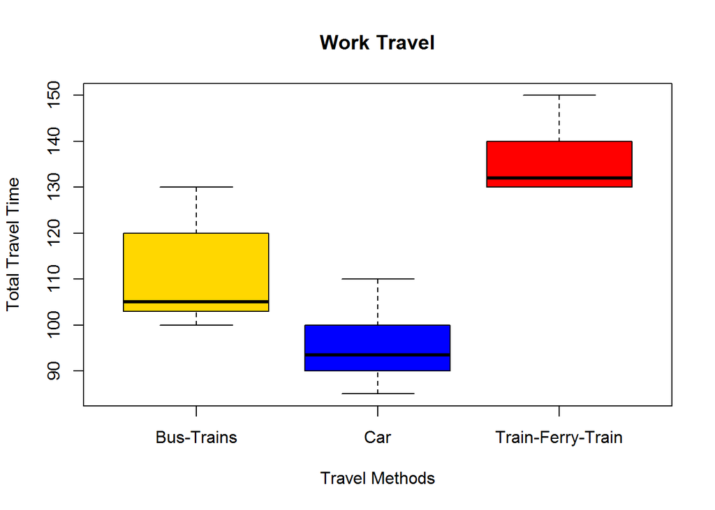

```r
plot(wt_sub_tr$totaltime~wt_sub_tr$method,
     main = "Work Travel",
     xlab="Travel Methods",
     ylab="Total Travel Time",
     col=c("gold","blue","red"))
```

With the summary table and the plot, we can conclude that it is faster if I take the car but more economical if I take the ferry to work. However, by alternating different routes througout the week, I can save on both time and money.

### **Probability**

**What is the probability that if I take the Bus to work, my wait time is no more than 5 mins?**

Let us look at the numbers for only bus:

```r
subset(wt, traveltype=="Leaving" & method=="Bus-Trains")
```

```
##   traveldate traveltype routeid waittime traffictime     method traveltime
## 1 2015-06-29    Leaving      R1       10           0 Bus-Trains         95
## 3 2015-06-30    Leaving      R1       10           0 Bus-Trains         95
## 5 2015-07-01    Leaving      R1        5           0 Bus-Trains         95
## 7 2015-07-02    Leaving      R1        8           0 Bus-Trains         95
## 9 2015-07-03    Leaving      R1        5           0 Bus-Trains         95
##   travelcost
## 1       6.75
## 3       6.75
## 5       6.75
## 7       6.75
## 9       6.75
```

Based on the sample gathered, the probability my wait time will be no more than 5 minutes is: 0.4.

**I left work at 3:30pm and I just reached home at 5:35pm. My husband thinks since the car was home and I’m over 2 hours late, I must have taken the ferry. What is the probability he is right?**

```r
subset(wt_sub_tr, (method=="Bus-Trains" | method=="Train-Ferry-Train") & type=="Arriving")
```

```
##        type            method totaltime cost
## 2  Arriving        Bus-Trains       125 6.75
## 4  Arriving        Bus-Trains       130 6.75
## 6  Arriving        Bus-Trains       105 6.75
## 8  Arriving        Bus-Trains       120 6.75
## 10 Arriving        Bus-Trains       115 6.75
## 12 Arriving Train-Ferry-Train       140 2.75
## 14 Arriving Train-Ferry-Train       145 2.75
## 16 Arriving Train-Ferry-Train       130 2.75
## 18 Arriving Train-Ferry-Train       150 2.75
## 20 Arriving Train-Ferry-Train       130 2.75
```

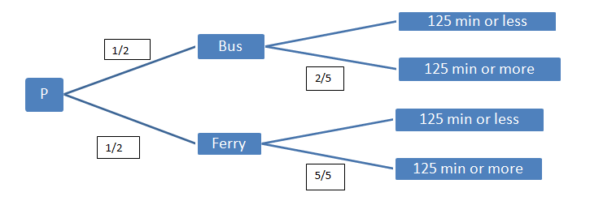

The probability that he is right is 71.42%.